# Cleaning Asthma Data

Ava

(February 26, 2020)

## Introduction

This notebook contains asthma data analyzed by Ava. ## Dependencies This notebook requires the following packages:

```r
# tidyverse packages
library(dplyr)       # data wrangling
library(readr)       # read/write tabular data
library(stringr)     # work with strings
library(tidyr)       # data wrangling
# spatial packages
library(janitor)     # data wrangling
library(sf)          # spatial data tools
library(mapview)     # projections
library(tigris)      # census data wrangling
# other packages
library(here)        # file path management
library(naniar)      # missing data
library(ggplot2)
library(viridis)      # palettes
library(tidycensus)
library(sp)
library(ggplot2)
library(RColorBrewer)  # color palettes
library(viridis)       # color palettes
```

## Load Data 2015

loading asthma data from MoPhim data base asthma is for 2015

```r
asthma <- read_csv(here("data", "asthma.csv"))
```

Getting rid of first three rows bc they are pointless text.

```r
asthma %>%
  slice(4:1029) -> asthma_sliced
```

Getting rid of third col with no data. aslo renaming cols to ‘count’ and ‘zip’

```r
asthma_sliced %>%
  select(-X3) %>%
  rename(count = `Missouri EPHT Asthma`) %>%
  rename(zip = `Title:`)-> asthma_sliced
```

Changing X to NA, making the count variable numeric

```r
mutate(asthma_sliced, count = ifelse(count == "x", NA, count)) -> asthma_cleaned
```

```r
mutate(asthma_sliced, count = as.numeric(count)) -> asthma_cleaned
```

```
NAs introduced by coercion
```

## Intermission for intro of Zip Codes

loading Mo zip codes

```r
moZip <- zctas(state = "Missouri", year = 2010,
               cb = FALSE, class ="sf")
```

```
ZCTAs can take several minutes to download.  To cache the data and avoid re-downloading in future R sessions, set `options(tigris_use_cache = TRUE)`
```

[output not shown]

Changing object to SF

```r
st_as_sf(moZip) -> moZip
```

cleaning names, selecting just cols for zip and geometry, changing col name to zip

```r
moZip %>%
  clean_names() %>%
  select(zcta5ce10, geometry) %>%
  rename(zip = `zcta5ce10`)-> moZip_clean
```

## Load Data 2014

loading data for asthma 2014

```r
asthma_14<- read_csv(here("data", "asthma2014.csv"))
```

getting rid of first three rows bc they have nothing in them

```r
asthma_14 %>%
  slice(4:1029) -> asthma14_sliced
```

getting rid of empty third col, renaming remaning cols

```r
asthma14_sliced %>%
  select(-X3) %>%
  rename(count = `Missouri EPHT Asthma`) %>%
  rename(zip = `Title:`) -> asthma14_sliced
```

changing X to NA, changing to numeric

```r
mutate(asthma14_sliced, count = ifelse(count == "x", NA, count)) -> asthma14_cleaned
```

```r
mutate(asthma14_sliced, count = as.numeric(count)) -> asthma14_cleaned
```

```
NAs introduced by coercion
```

left join to asthma_cleaned by zip. Now table has data for both 2014 and 2015

```r
left_join(asthma_cleaned, asthma14_cleaned, by = "zip") -> joined_14_15
```

## Load Data 2013

loading asthma data for 2013

```r
asthma_2013 <- read_csv(here("data", "asthma2013.csv"))
```

[output not shown]

```r
asthma_2013 %>%
  slice(4:1029) -> asthma13_sliced
```

getting rid of third col, renaming other cols

```r
asthma13_sliced %>%
  select(-X3) %>%
  rename(count_13 = `Missouri EPHT Asthma`) %>%
  rename(zip = `Title:`) -> asthma13_sliced
```

changing X to NA, changing count to numeric

```r
mutate(asthma13_sliced, count_13 = ifelse(count_13 == "x", NA, count_13)) -> asthma13_cleaned
```

```r
mutate(asthma13_sliced, count_13 = as.numeric(count_13)) -> asthma13_cleaned
```

```
NAs introduced by coercion
```

left joining to joined_14_15, so table now has data for years 2013, 2014, and 2015

```r
left_join(joined_14_15, asthma13_cleaned, by = "zip") -> joined_13_14_15
```

## Load Data 2012

loading data for 2012

```r
asthma_2012 <- read_csv(here("data", "asthma2012.csv"))
```

[output not shown]

getting rid of empty cols

```r
asthma_2012 %>%
  slice(4:1029) -> asthma12_sliced
```

cleaning data

```r
asthma12_sliced %>%
  select(-X3) %>%
  rename(count_12 = `Missouri EPHT Asthma`) %>%
  rename(zip = `Title:`) -> asthma12_sliced
```

changing X to NA and changing count to numeric

```r
mutate(asthma12_sliced, count_12 = ifelse(count_12 == "x", NA, count_12)) -> asthma12_cleaned
```

```r
mutate(asthma12_sliced, count_12 = as.numeric(count_12)) -> asthma12_cleaned
```

```
NAs introduced by coercion
```

left joining to joined_13_14_15 by zip. Table now has data for 2012 through 2015

```r
left_join(joined_13_14_15, asthma12_cleaned, by = "zip") -> joined12_15
```

## Load Data 2011

loading data for 2011

```r
asthma_2011 <- read_csv(here("data", "asthma2011.csv"))
```

[output not shown]

getting rid of empty cols

```r
asthma_2011 %>%
  slice(4:1029) -> asthma11_sliced
```

cleaning data

```r
asthma11_sliced %>%
  select(-X3) %>%
  rename(count_11 = `Missouri EPHT Asthma`) %>%
  rename(zip = `Title:`) -> asthma11_sliced
```

changing X to NA, and changing count to be numeric

```r
mutate(asthma11_sliced, count_11 = ifelse(count_11 == "x", NA, count_11)) -> asthma11_cleaned
```

```r
mutate(asthma11_sliced, count_11 = as.numeric(count_11)) -> asthma11_cleaned
```

```
NAs introduced by coercion
```

## Joining data for years 2011-2015

joining to joined_12_15 for years 2011-2015

```r
left_join(joined12_15, asthma11_cleaned, by = "zip") -> joined11_15
```

joining data with geometry by zip

```r
asthma_full_11_15 <- left_join(moZip_clean, joined11_15, by = "zip")
```

```r
asthma_full_11_15 %>%
rename(
  count_14 = count.y,
  count_15 = count.x
) -> asthma_full_11_15
# See line514 for small multiples
```

[output not shown]

## Zip codes for St Louis metro area

filtering for Zip codes in St Louis Metro Area, first filter gets range, Exclude gets rid of zip codes in that range that aren’t included in the metro area.

```r
asthma_full_11_15 %>%
  filter(zip >= (63005))%>%
  filter(zip <= (63390)) -> asthma_metro
```

```r
exclude <- c(63091, 63155, 63333, 63334, 63336, 63339, 63344, 63345, 63350, 63351, 63352, 63353, 63359, 63359, 63361, 63363, 63382, 63388, 63384, 63036, 63087, 63330)
```

```r
asthma_metro %>%
filter(as.character(zip) %in% exclude == FALSE) -> asthma_metro_2
```

changing NA’s to 0s

```r
asthma_metro_2 %>%
  mutate(count_11 = ifelse(is.na(count_11) == TRUE, 0, count_11)) %>%
  mutate(count_12 = ifelse(is.na(count_12) == TRUE, 0, count_12)) %>%
  mutate(count_13 = ifelse(is.na(count_13) == TRUE, 0, count_13)) %>%
  mutate(count_14 = ifelse(is.na(count_14) == TRUE, 0, count_14)) %>%
  mutate(count_15 = ifelse(is.na(count_15) == TRUE, 0, count_15))-> asthma_metro_2
```

## Creating Count variable

Creating count for all 5 years

```r
asthma_metro_2 %>%
  group_by(zip) %>%
  mutate(total = sum(count_15, count_14, count_13, count_12, count_11)) %>%
  select(zip, total, geometry) -> asthma_count_total
```

rowwise() %>% getting census data to get population for zip code tracts. using 5 year estimates from 2015

```r
acs <- load_variables(year = 2015, dataset = "acs5", cache = TRUE)
```

```r
pop <- get_acs(geography = "zip code tabulation area", year = 2015, variables = "B01003_001", survey = "acs5")
```

filtering for zip codes in st. louis metro area

```r
pop %>%
  filter(GEOID >= (63005))%>%
  filter(GEOID <= (63390)) ->pop
```

```r
pop %>%
  filter(as.character(GEOID) %in% exclude == FALSE)%>%
  rename(zip = GEOID,
         pop = estimate) %>%
  select(zip, pop) -> pop_metro
```

left join pop_metro to asthma_count_total, making variable for count

```r
left_join(asthma_count_total, pop_metro, by = "zip") %>%
  mutate(count = (total/pop)*1000) %>%
 select(zip, count, geometry) -> count_by_pop
```

```r
mapview(count_by_pop)
```

[output not shown]

creating ggplot map

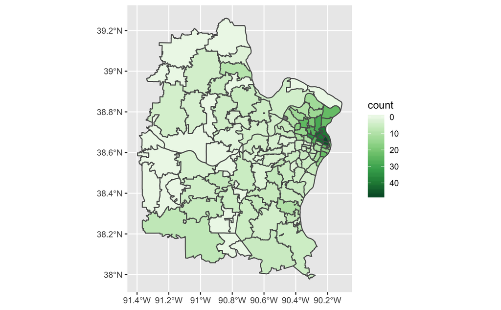

```r
ggplot() +
    geom_sf(data = count_by_pop, mapping = aes(fill = count)) +
  scale_fill_distiller(palette = "Greens", trans ="reverse")
```

## saving csv file for Asthma data for years 2011-2015

```r
write.csv(count_by_pop, here("data","csv", "asthmaCount11_15.csv"))
```

## loading Data for % African American

loading data for year 2015 (five year estimate)

```r
aa <- get_acs(geography = "zip code tabulation area", year = 2015, variables = "B02009_001", survey = "acs5")
```

Joining with pop data

```r
aa <- left_join(aa, pop, by = "GEOID")
```

normalizing by pop

```r
aa %>%
mutate(percent = estimate.x/estimate.y) %>%
  rename(zip = GEOID) -> aa
```

join with asthma data

```r
aa_metro <- left_join(count_by_pop, aa, by = "zip")
```

saving csv file for % african american

```r
write.csv(aa_metro, here("data","csv", "percent_aa.csv"))
```

saving as shapefile

```r
dir.create(here("data","csv", "precent_aa"))
```

```
'/Users/emilymccarthy/Documents/GitHub/redliningAsthma-Zipcode/data/csv/precent_aa' already exists
```

```r
st_write(aa_metro, dsn = here("data","csv","precent_aa", "precent_aa.shp"), delete_dsn = TRUE)
```

[output not shown]

```
Deleting source `/Users/emilymccarthy/Documents/GitHub/redliningAsthma-Zipcode/data/csv/precent_aa/precent_aa.shp' failed
Writing layer `precent_aa' to data source `/Users/emilymccarthy/Documents/GitHub/redliningAsthma-Zipcode/data/csv/precent_aa/precent_aa.shp' using driver `ESRI Shapefile'
Writing 127 features with 11 fields and geometry type Multi Polygon.
```

## loading data for median income

loading five year estimate for 2015

```r
median_income <- get_acs(geography = "zip code tabulation area", year = 2015, variables = "B06011_001", survey = "acs5")
```

join with pop data

```r
median_income <- left_join(median_income, pop, by = "GEOID")
```

normalize by pop

```r
median_income%>%
mutate(percent = estimate.x/estimate.y) %>%
rename(zip = GEOID) -> median_income
```

join with asthma data

```r
median_income <- left_join(count_by_pop, median_income, by = "zip")
```

saving csv file for median income

```r
write.csv(median_income, here("data","csv", "median_income.csv"))
```

saving as shapefile

```r
dir.create(here("data","csv", "median_income"))
st_write(median_income, dsn = here("data","csv","median_income", "median_income.shp"), delete_dsn = TRUE)
```

## loading data for median home value

loading 5 year estimate from 2015

```r
home_value <- get_acs(geography = "zip code tabulation area", year = 2015, variables = "B25077_001", survey = "acs5")
```

joining with pop data

```r
home_value <- left_join(home_value, pop, by = "GEOID")
```

normalizing by pop

```r
home_value%>%
mutate(percent = estimate.x/estimate.y) %>%
rename(zip = GEOID) -> home_value
```

joining with asthma data

```r
home_metro <- left_join(count_by_pop, home_value, by = "zip")
```

Saving csv file for median home value

```r
write.csv(home_metro, here("data","csv", "median_home.csv"))
```

saving as shapefile

```r
dir.create(here("data","csv", "home_value"))
st_write(home_metro, dsn = here("data","csv","home_value", "home_value.shp"), delete_dsn = TRUE)
```

## loading data for medicaide

loading five year estimate from 2015

```r
medicaid <- get_acs(geography = "zip code tabulation area", year = 2015, variables = "B992707_001", survey = "acs5")
```

joining with pop

```r
medicaid <- left_join(medicaid, pop, by = "GEOID")
```

normalizing by pop

```r
medicaid %>%
mutate(percent = estimate.x/estimate.y) %>%
rename(zip = GEOID) -> medicaid
```

joining with asthma data

```r
med_metro <- left_join(count_by_pop, medicaid, by = "zip")
```

saving csv file

```r
write.csv(med_metro, here("data","csv", "medicaid.csv"))
```

saving as shapefile

```r
dir.create(here("data","csv", "medicaid"))
```

```
'/Users/emilymccarthy/Documents/GitHub/redliningAsthma-Zipcode/data/csv/medicaid' already exists
```

```r
st_write(med_metro, dsn = here("data","csv","medicaid", "medicaid.shp"), delete_dsn = TRUE)
```

[output not shown]

```
Deleting source `/Users/emilymccarthy/Documents/GitHub/redliningAsthma-Zipcode/data/csv/medicaid/medicaid.shp' failed
Writing layer `medicaid' to data source `/Users/emilymccarthy/Documents/GitHub/redliningAsthma-Zipcode/data/csv/medicaid/medicaid.shp' using driver `ESRI Shapefile'
Writing 127 features with 10 fields and geometry type Multi Polygon.
```

## loading data for % under poverty line

loading five year estimates for 2015

```r
poverty <- get_acs(geography = "zip code tabulation area", year = 2015, variables = "B17001_002", survey = "acs5")
```

loading poverty total

```r
poverty_total <- get_acs(geography = "zip code tabulation area", year = 2015, variables = "B17001_001", survey = "acs5")
```

```r
poverty %>%
  select(GEOID, estimate) -> poverty
```

```r
poverty <- left_join(poverty, poverty_total, by = "GEOID")
```

normalizing by povery total

```r
poverty %>%
  mutate(density = estimate.x/estimate.y) %>%
  rename(zip = GEOID) -> poverty
```

joining with asthma data

```r
poverty_metro <- left_join(count_by_pop, poverty, by = "zip")
```

saving as csv file

```r
write.csv(poverty_metro, here("data","csv", "poverty.csv"))
```

```r
dir.create(here("data","csv", "poverty"))
```

```
'/Users/emilymccarthy/Documents/GitHub/redliningAsthma-Zipcode/data/csv/poverty' already exists
```

```r
st_write(poverty_metro, dsn = here("data","csv","poverty", "poverty.shp"), delete_dsn = TRUE)
```

[output not shown]

```
Deleting source `/Users/emilymccarthy/Documents/GitHub/redliningAsthma-Zipcode/data/csv/poverty/poverty.shp' failed
Writing layer `poverty' to data source `/Users/emilymccarthy/Documents/GitHub/redliningAsthma-Zipcode/data/csv/poverty/poverty.shp' using driver `ESRI Shapefile'
Writing 127 features with 8 fields and geometry type Multi Polygon.
```

## Small Multiples Asthma

download county geometry, st_clip, just stlc and county

Adding county geometry

```r
counties <- st_read(here("data", "METRO_BOUNDARY_Counties", "METRO_BOUNDARY_Counties.shp"), stringsAsFactors = FALSE)
```

```r
counties %>%
  filter(COUNTYFP %in% c(189, 510)) -> metrocounties
```

```r
asthma_metro_2 <- st_transform(asthma_metro_2, 26915)
mapview::mapview(metrocounties)
```

[interactive chart not shown]

```r
st_intersection(asthma_metro_2, metrocounties) -> asthma_metro_2
```

```
attribute variables are assumed to be spatially constant throughout all geometries
```

```r
intersect <- st_collection_extract(asthma_metro_2, "POLYGON")
```

#### NEXT WEEK

-44x40 in poster - 6 maps -st_intersection -works the same as st_crop - but it returns a geometry selection so instead -RColorBrewer

2015 Asthma Hospitalizations

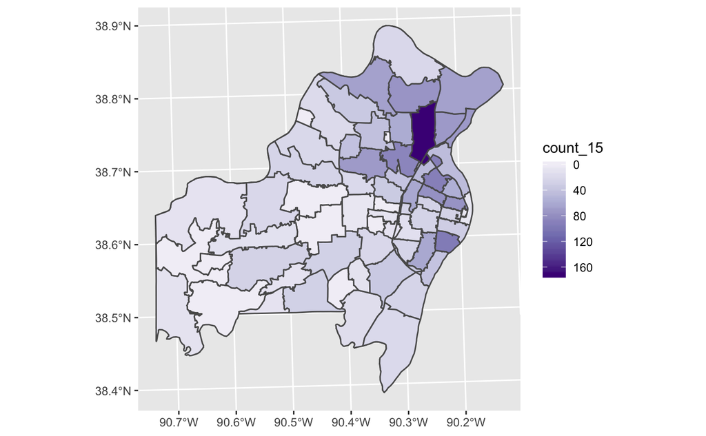

```r
ggplot() +
  geom_sf(data = intersect, mapping = aes(fill = count_15)) +
  scale_fill_distiller(palette = "Purples", trans ="reverse")
```

2014 Hospitalizations

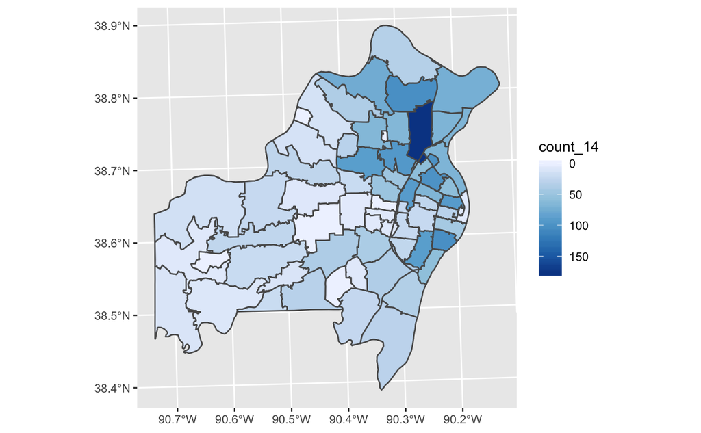

```r
ggplot() +
    geom_sf(data = intersect, mapping = aes(fill = count_14)) +
  scale_fill_distiller(palette = "Blues", trans ="reverse")
```

2013 Hospitalizations

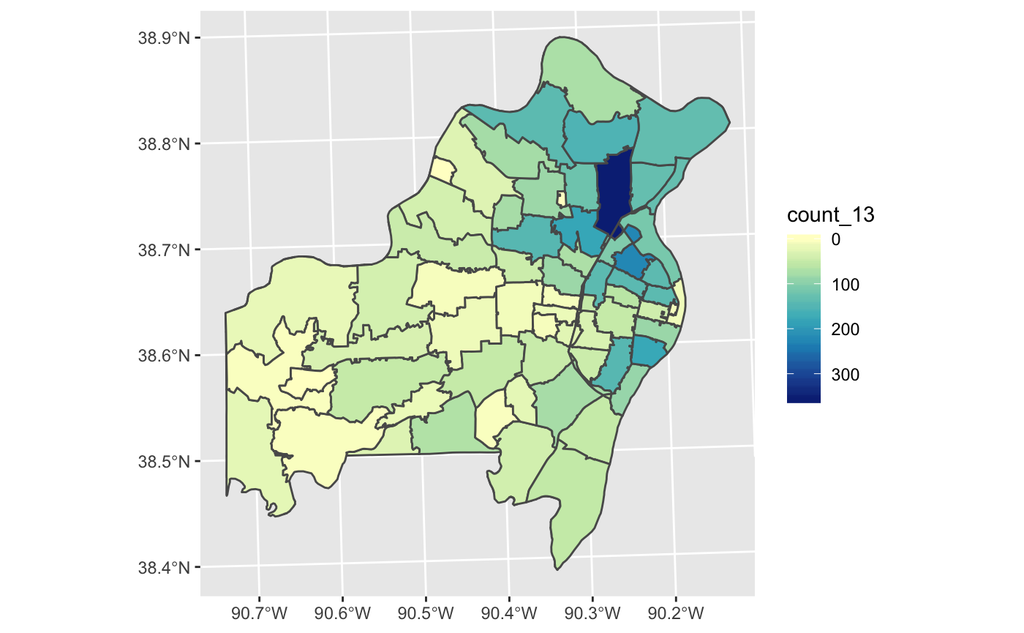

```r
ggplot() +
    geom_sf(data = intersect, mapping = aes(fill = count_13)) +
  scale_fill_distiller(palette = "YlGnBu", trans ="reverse")
```

2012 Hospitalizations

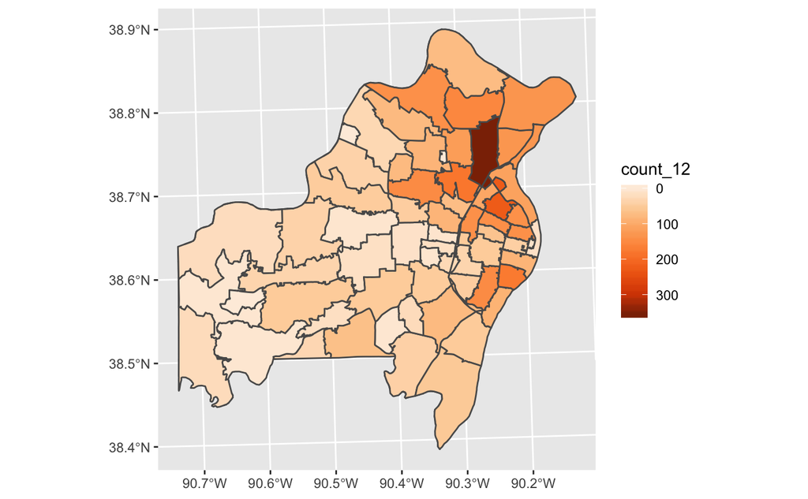

```r
ggplot() +
    geom_sf(data = intersect, mapping = aes(fill = count_12)) +
  scale_fill_distiller(palette = "Oranges", trans ="reverse")
```

2011 Hospitalizations

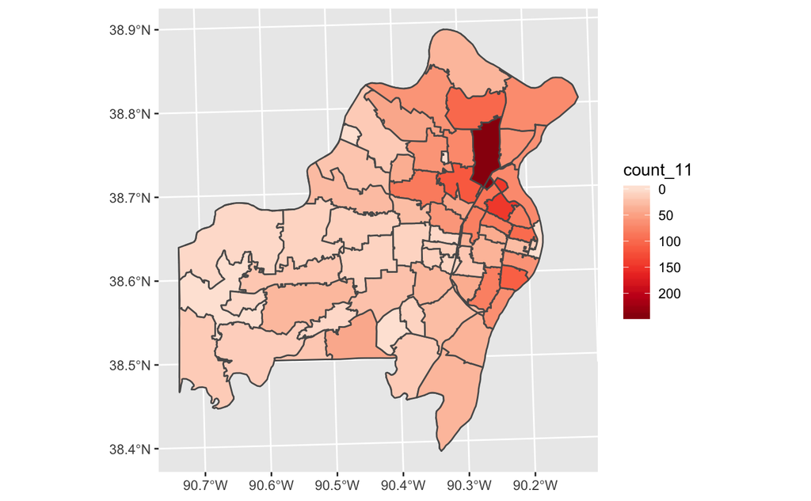

```r
ggplot() +
    geom_sf(data = intersect, mapping = aes(fill = count_11)) +
  scale_fill_distiller(palette = "Reds", trans ="reverse")
```

```r
dir.create(here("data","maps", "metro"))
```

```
cannot create dir '/Users/emilymccarthy/Documents/GitHub/redliningAsthma-Zipcode/data/maps/metro', reason 'No such file or directory'
```

```r
st_write(plot15, dsn = here("data","maps","metro", "plot15.png"), delete_dsn = TRUE)
```

[output not shown]